# Practical Machine Learning Course Project

John Moses

January 31, 2020

## Overview

Using devices such as Jawbone Up, Nike FuelBand, and Fitbit it is now possible to collect a large amount of data about personal activity relatively inexpensively. These type of devices are part of the quantified self movement – a group of enthusiasts who take measurements about themselves regularly to improve their health, to find patterns in their behavior, or because they are tech geeks. One thing that people regularly do is quantify how much of a particular activity they do, but they rarely quantify how well they do it. In this project, your goal will be to use data from accelerometers on the belt, forearm, arm, and dumbell of 6 participants. They were asked to perform barbell lifts correctly and incorrectly in 5 different ways. More information is available from the website here: http://groupware.les.inf.puc-rio.br/har (see the section on the Weight Lifting Exercise Dataset).

The training data for this project are available here:

https://d396qusza40orc.cloudfront.net/predmachlearn/pml-training.csv

The test data are available here:

https://d396qusza40orc.cloudfront.net/predmachlearn/pml-testing.csv

The data for this project come from this source: http://groupware.les.inf.puc-rio.br/har. If you use the document you create for this class for any purpose please cite them as they have been very generous in allowing their data to be used for this kind of assignment.

## Data Prep

Load packages and training and test data

```r
library(caret)
```

```r
library(rpart)
library(rpart.plot)
library(RColorBrewer)
library(rattle)
library(randomForest)
library(corrplot)
library(gbm)
library(e1071)
# URL for the download
UrlTrain <- "https://d396qusza40orc.cloudfront.net/predmachlearn/pml-training.csv"
UrlTest  <- "https://d396qusza40orc.cloudfront.net/predmachlearn/pml-testing.csv"

#read cvs files to dataframes
dat_training <- read.csv(url(UrlTrain))
dat_testing  <- read.csv(url(UrlTest))

#examine data
dim(dat_training)
```

```
## [1] 19622   160
```

```r
dim(dat_testing)
```

```
## [1]  20 160
```

There are 19,622 observations and 160 variables in the training data set.

## Cleaning Data

Remove variables that are zero or contain missing values.

```r
dat1_training <- dat_training[, colSums(is.na(dat_training)) == 0]
dat1_testing <- dat_testing[, colSums(is.na(dat_testing))==0]
dim(dat1_training)
```

```
## [1] 19622    93
```

```r
dim(dat1_testing)
```

```
## [1] 20 60
```

The first seven variables have no impact on the analysis, so they are removed.

```r
#examine first seven variables
head(dat1_training[,1:7])
```

```
##   X user_name raw_timestamp_part_1 raw_timestamp_part_2   cvtd_timestamp
## 1 1  carlitos           1323084231               788290 05/12/2011 11:23
## 2 2  carlitos           1323084231               808298 05/12/2011 11:23
## 3 3  carlitos           1323084231               820366 05/12/2011 11:23
## 4 4  carlitos           1323084232               120339 05/12/2011 11:23
## 5 5  carlitos           1323084232               196328 05/12/2011 11:23
## 6 6  carlitos           1323084232               304277 05/12/2011 11:23
##   new_window num_window
## 1         no         11
## 2         no         11
## 3         no         11
## 4         no         12
## 5         no         12
## 6         no         12
```

```r
#remove first seven variables
dat1_training <- dat1_training[, -c(1:7)]
dat1_testing <- dat1_testing[, -c(1:7)]

dim(dat1_training)
```

```
## [1] 19622    86
```

```r
dim(dat1_testing)
```

```
## [1] 20 53
```

## Data Prep for Predictions

Training data will be split 70% for training and 30% for testing. The split will be used to calculate out-of-sample errors.

```r
set.seed(47)

dat2_train <- createDataPartition(dat1_training$classe, p=0.7, list=FALSE)
train_dat <- dat1_training[dat2_train,]
test_dat <- dat1_training[-dat2_train,]

dim(train_dat)
```

```
## [1] 13737    86
```

```r
dim(test_dat)
```

```
## [1] 5885   86
```

# Remove Variables with Near-Zero-Variance

```r
nzv <- nearZeroVar(train_dat)
train_dat <- train_dat[, -nzv]
test_dat <- test_dat[, -nzv]

dim(train_dat)
```

```
## [1] 13737    53
```

```r
dim(test_dat)
```

```
## [1] 5885   53
```

Correlation plot will be used to find correlated predictors

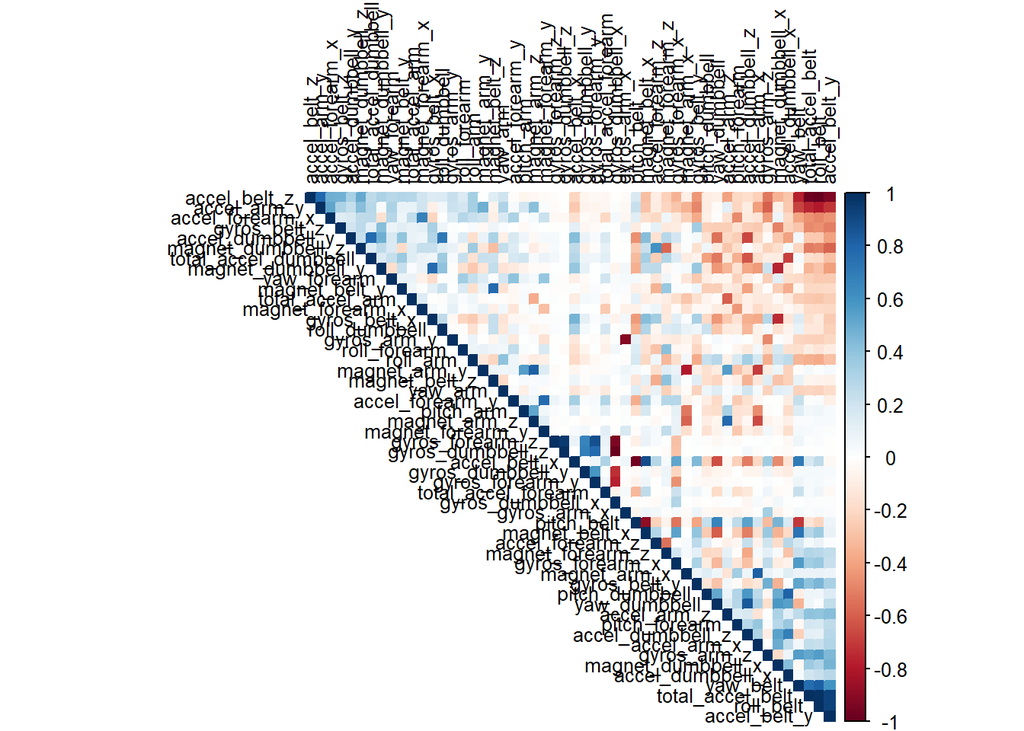

```r
cor_matrix <- cor(train_dat[, -53])
corrplot(cor_matrix, order = "FPC", method = "color", type = "upper",
         tl.cex = 0.8, tl.col = rgb(0, 0, 0))
```

Locate the names of the highly correlated variables using the findCorrelation function.

```r
high_corr <- findCorrelation(cor_matrix, cutoff = 0.75)

#Names of high correlated variables
names(train_dat[high_corr])
```

```
##  [1] "accel_belt_z"      "roll_belt"         "accel_belt_y"
##  [4] "total_accel_belt"  "accel_dumbbell_z"  "accel_belt_x"
##  [7] "pitch_belt"        "magnet_dumbbell_x" "accel_dumbbell_y"
## [10] "magnet_dumbbell_y" "accel_dumbbell_x"  "accel_arm_x"
## [13] "accel_arm_z"       "magnet_arm_y"      "magnet_belt_z"
## [16] "accel_forearm_y"   "gyros_forearm_y"   "gyros_dumbbell_x"
## [19] "gyros_dumbbell_z"  "gyros_arm_x"
```

## Model Building

Classification tree and random forest will be used to predict outcome.

# Classification Tree Prediction

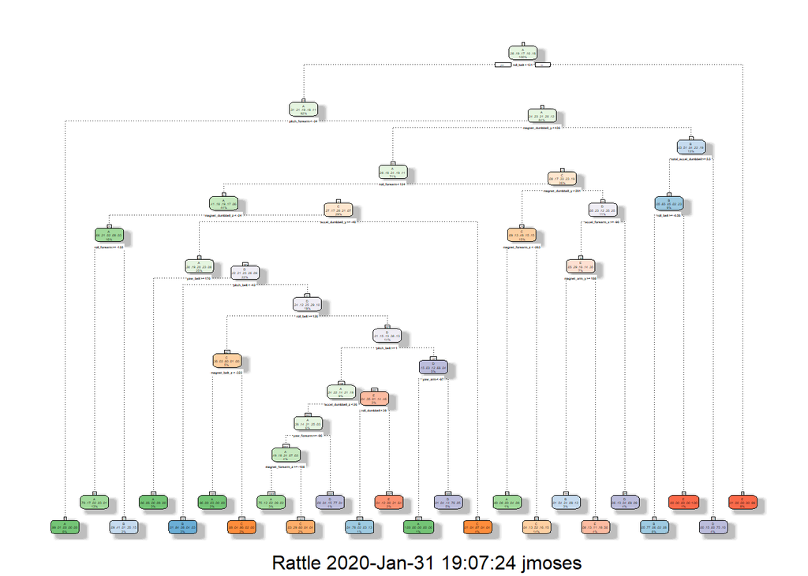

```r
set.seed(47)
decisionTree.1 <- rpart(classe ~ ., data=train_dat, method = "class")
fancyRpartPlot(decisionTree.1)
```

Validate on test_dat data

```r
predictTree.1 <- predict(decisionTree.1, test_dat, type = "class")
cmtree <- confusionMatrix(predictTree.1, test_dat$classe)
cmtree
```

```
## Confusion Matrix and Statistics
##
##           Reference
## Prediction    A    B    C    D    E
##          A 1515  169   22   47   19
##          B   65  653   88   89   99
##          C   42  169  819  137  127
##          D   22   89   72  622   56
##          E   30   59   25   69  781
##
## Overall Statistics
##
##                Accuracy : 0.746
##                  95% CI : (0.7346, 0.757)
##     No Information Rate : 0.2845
##     P-Value [Acc > NIR] : < 2.2e-16
##
##                   Kappa : 0.6781
##
##  Mcnemar's Test P-Value : < 2.2e-16
##
## Statistics by Class:
##
##                      Class: A Class: B Class: C Class: D Class: E
## Sensitivity            0.9050   0.5733   0.7982   0.6452   0.7218
## Specificity            0.9390   0.9282   0.9022   0.9514   0.9619
## Pos Pred Value         0.8550   0.6569   0.6329   0.7224   0.8102
## Neg Pred Value         0.9613   0.9006   0.9549   0.9319   0.9388
## Prevalence             0.2845   0.1935   0.1743   0.1638   0.1839
## Detection Rate         0.2574   0.1110   0.1392   0.1057   0.1327
## Detection Prevalence   0.3011   0.1689   0.2199   0.1463   0.1638
## Balanced Accuracy      0.9220   0.7507   0.8502   0.7983   0.8419
```

Plot of Matrix Results

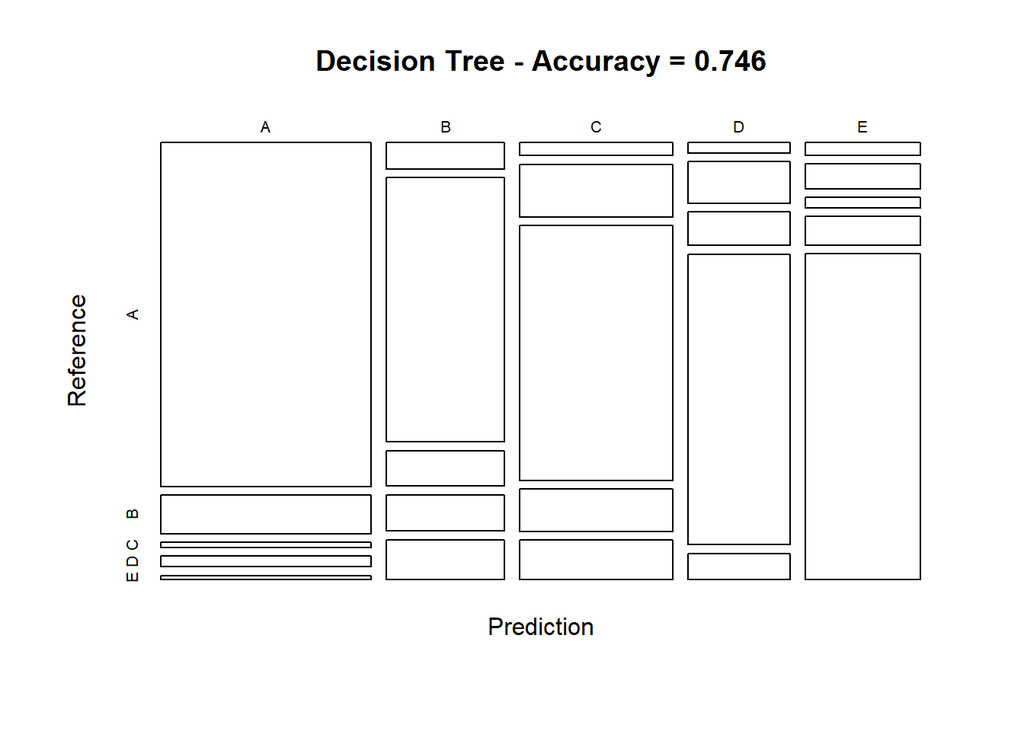

```r
# plot matrix results
plot(cmtree$table, col = cmtree$byClass,
     main = paste("Decision Tree - Accuracy =", round(cmtree$overall['Accuracy'], 4)))
```

Accuracy rate is 0.746. Out-of-sample rate is about 0.25.

## Random Forest Model

```r
controlRF <- trainControl(method="cv", number=3, verboseIter = FALSE)
modelRF.1 <- train(classe ~ ., data=train_dat, method ="rf", trControl=controlRF)
modelRF.1$finalModel
```

```
##
## Call:
##  randomForest(x = x, y = y, mtry = param$mtry)
##                Type of random forest: classification
##                      Number of trees: 500
## No. of variables tried at each split: 2
##
##         OOB estimate of  error rate: 0.74%
## Confusion matrix:
##      A    B    C    D    E class.error
## A 3902    4    0    0    0 0.001024066
## B   10 2634   13    1    0 0.009029345
## C    0   18 2376    2    0 0.008347245
## D    0    0   42 2207    3 0.019982238
## E    0    0    3    5 2517 0.003168317
```

Validate on the test_dat data

```r
predictRF <- predict(modelRF.1, newdata = test_dat)
cmrf <- confusionMatrix(predictRF, test_dat$classe)
cmrf
```

```
## Confusion Matrix and Statistics
##
##           Reference
## Prediction    A    B    C    D    E
##          A 1671   11    0    0    0
##          B    3 1121    8    0    0
##          C    0    7 1016    4    0
##          D    0    0    2  959    0
##          E    0    0    0    1 1082
##
## Overall Statistics
##
##                Accuracy : 0.9939
##                  95% CI : (0.9915, 0.9957)
##     No Information Rate : 0.2845
##     P-Value [Acc > NIR] : < 2.2e-16
##
##                   Kappa : 0.9923
##
##  Mcnemar's Test P-Value : NA
##
## Statistics by Class:
##
##                      Class: A Class: B Class: C Class: D Class: E
## Sensitivity            0.9982   0.9842   0.9903   0.9948   1.0000
## Specificity            0.9974   0.9977   0.9977   0.9996   0.9998
## Pos Pred Value         0.9935   0.9903   0.9893   0.9979   0.9991
## Neg Pred Value         0.9993   0.9962   0.9979   0.9990   1.0000
## Prevalence             0.2845   0.1935   0.1743   0.1638   0.1839
## Detection Rate         0.2839   0.1905   0.1726   0.1630   0.1839
## Detection Prevalence   0.2858   0.1924   0.1745   0.1633   0.1840
## Balanced Accuracy      0.9978   0.9909   0.9940   0.9972   0.9999
```

Accuracy is high, 0.9939, out of sample error 0.0061

Plot of the Random Forest model

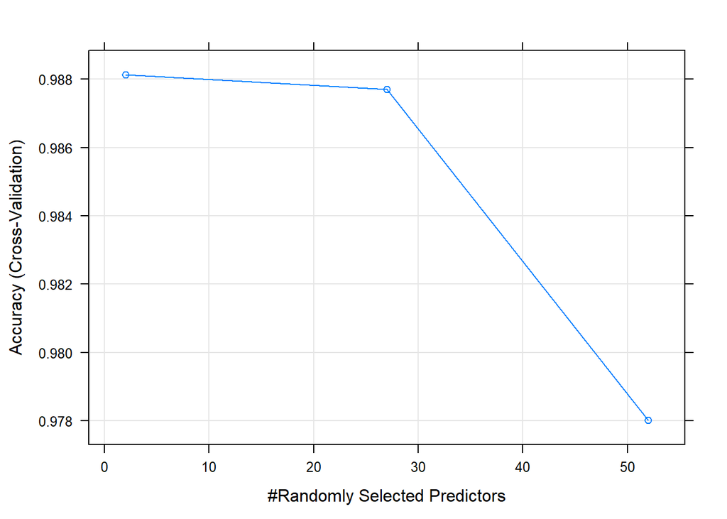

```r
plot(modelRF.1)
```

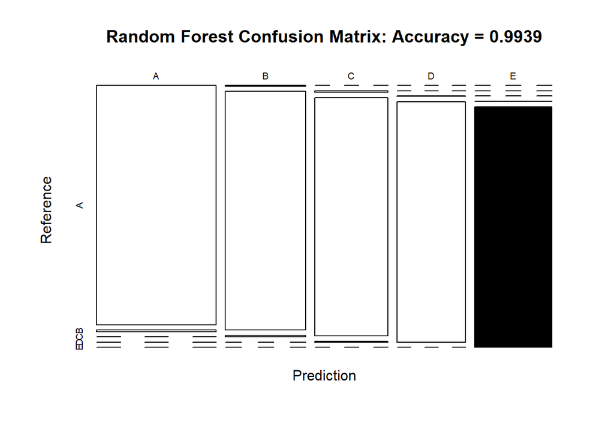

```r
plot(cmrf$table, col = cmrf$byClass, main = paste("Random Forest Confusion Matrix: Accuracy =", round(cmrf$overall['Accuracy'], 4)))
```

## Generalized Boost Regression

```r
set.seed(47)
controlGBM <- trainControl(method = "repeatedcv", number = 5, repeats = 1)
modGBM  <- train(classe ~ ., data=train_dat, method = "gbm", trControl = controlGBM, verbose = FALSE)
modGBM$finalModel
```

```
## A gradient boosted model with multinomial loss function.
## 150 iterations were performed.
## There were 52 predictors of which 52 had non-zero influence.
```

```r
print(modGBM)
```

```
## Stochastic Gradient Boosting
##
## 13737 samples
##    52 predictor
##     5 classes: 'A', 'B', 'C', 'D', 'E'
##
## No pre-processing
## Resampling: Cross-Validated (5 fold, repeated 1 times)
## Summary of sample sizes: 10988, 10988, 10991, 10991, 10990
## Resampling results across tuning parameters:
##
##   interaction.depth  n.trees  Accuracy   Kappa
##   1                   50      0.7513287  0.6845846
##   1                  100      0.8220851  0.7747208
##   1                  150      0.8525141  0.8133486
##   2                   50      0.8549907  0.8162292
##   2                  100      0.9055098  0.8804155
##   2                  150      0.9280031  0.9088946
##   3                   50      0.8966284  0.8691364
##   3                  100      0.9415423  0.9260256
##   3                  150      0.9593046  0.9485098
##
## Tuning parameter 'shrinkage' was held constant at a value of 0.1
##
## Tuning parameter 'n.minobsinnode' was held constant at a value of 10
## Accuracy was used to select the optimal model using the largest value.
## The final values used for the model were n.trees = 150,
##  interaction.depth = 3, shrinkage = 0.1 and n.minobsinnode = 10.
```

Validate Generalized Boost Model

```r
predictGBM <- predict(modGBM, newdata=test_dat)
cmGBM <- confusionMatrix(predictGBM, test_dat$classe)
cmGBM
```

```
## Confusion Matrix and Statistics
##
##           Reference
## Prediction    A    B    C    D    E
##          A 1657   25    0    3    3
##          B   12 1078   39    6   17
##          C    4   31  971   22    5
##          D    1    2   14  932   11
##          E    0    3    2    1 1046
##
## Overall Statistics
##
##                Accuracy : 0.9658
##                  95% CI : (0.9609, 0.9703)
##     No Information Rate : 0.2845
##     P-Value [Acc > NIR] : < 2.2e-16
##
##                   Kappa : 0.9568
##
##  Mcnemar's Test P-Value : 6.431e-05
##
## Statistics by Class:
##
##                      Class: A Class: B Class: C Class: D Class: E
## Sensitivity            0.9898   0.9464   0.9464   0.9668   0.9667
## Specificity            0.9926   0.9844   0.9872   0.9943   0.9988
## Pos Pred Value         0.9816   0.9358   0.9400   0.9708   0.9943
## Neg Pred Value         0.9959   0.9871   0.9887   0.9935   0.9926
## Prevalence             0.2845   0.1935   0.1743   0.1638   0.1839
## Detection Rate         0.2816   0.1832   0.1650   0.1584   0.1777
## Detection Prevalence   0.2868   0.1958   0.1755   0.1631   0.1788
## Balanced Accuracy      0.9912   0.9654   0.9668   0.9806   0.9827
```

Accuracy for Generalize Boost Regression Model is0.9658. Out-of-sample error is 0.0342.

## BEST MODEL

Random Forest model has the highest accuracy, and will be used for the test data set.

```r
results <- predict(modelRF.1, newdata = dat1_testing)
results
```

```
##  [1] B A B A A E D B A A B C B A E E A B B B
## Levels: A B C D E
```